# Guided Project: Statistical Transformations and Coordinate Systems

CIS-3901 · Module 12

Author

Monty Edwards

Published

November 19, 2026

## My data

For Part A, I used the Adult dataset (`fairness.csv`), where each row represents an individual demographic and income record (5,000 rows total), sourced from the Fairlearn repository and originally extracted from the 1994 U.S. Census Bureau database. For Part B, I used the NFL Draft Combine dataset (`sports.csv`), where each row represents a combine prospect (6,128 rows total), sourced from the SCORE Network repository.

```r
put_in_place("fairness.csv", "data/tidy")
put_in_place("sports.csv", "data/sports")

fairness <- read_csv("data/tidy/fairness.csv", show_col_types = FALSE)
sports <- read_csv("data/sports/sports.csv", show_col_types = FALSE)

if (looks_damaged(fairness) || looks_damaged(sports)) {
  stop("One of your data files looks damaged (each row in one column): it ",
       "may have been re-saved by a spreadsheet app. Ask your instructor ",
       "for a fresh copy.", call. = FALSE)
}

# Your columns
glimpse(fairness)
```

```
Rows: 5,000
Columns: 15
$ person_id      <dbl> 1, 2, 3, 4, 5, 6, 7, 8, 9, 10, 11, 12, 13, 14, 15, 16, …
$ age            <dbl> 54, 28, 42, 38, 33, 33, 46, 42, 47, 61, 46, 33, 18, 28,…
$ workclass      <chr> "Private", "Private", "Private", "State-gov", "Private"…
$ education      <chr> "HS-grad", "Assoc-acdm", "10th", "Some-college", "Some-…
$ education_num  <dbl> 9, 12, 6, 10, 10, 9, 10, 2, 14, 10, 9, 9, 9, 13, 9, 9, …
$ marital_status <chr> "Divorced", "Married-civ-spouse", "Divorced", "Separate…
$ occupation     <chr> "Craft-repair", "Exec-managerial", "Adm-clerical", "Exe…
$ relationship   <chr> "Not-in-family", "Wife", "Unmarried", "Not-in-family", …
$ race           <chr> "White", "White", "White", "White", "White", "Black", "…
$ sex            <chr> "Male", "Female", "Female", "Female", "Male", "Female",…
$ capital_gain   <dbl> 0, 0, 0, 0, 0, 0, 0, 0, 0, 0, 0, 0, 0, 0, 0, 0, 0, 0, 0…
$ capital_loss   <dbl> 1741, 0, 0, 0, 0, 0, 0, 0, 0, 0, 0, 0, 0, 0, 0, 0, 0, 0…
$ hours_per_week <dbl> 40, 16, 40, 45, 40, 40, 40, 55, 45, 40, 40, 40, 48, 47,…
$ native_country <chr> "United-States", "United-States", "United-States", "Uni…
$ income         <chr> "<=50K", ">50K", "<=50K", "<=50K", "<=50K", "<=50K", ">…
```

```r
glimpse(sports)
```

```
Rows: 6,128
Columns: 8
$ position   <chr> "QB", "RB", "QB", "QB", "WR", "OT", "WR", "WR", "WR", "RB",…
$ Round      <dbl> NA, NA, NA, NA, NA, NA, NA, NA, NA, NA, NA, NA, NA, NA, NA,…
$ forty      <dbl> 4.79, 4.50, 4.60, 4.95, 4.78, 5.41, 4.76, 4.73, 4.59, 4.71,…
$ vertical   <dbl> 30.5, 34.0, NA, 30.0, 38.0, 28.0, 31.5, 38.0, 28.5, 31.5, 2…
$ bench_reps <dbl> NA, 21, NA, NA, NA, 20, NA, NA, NA, 16, NA, NA, NA, 28, 18,…
$ broad_jump <dbl> 110, 121, NA, 119, 118, 104, 116, 128, 111, 108, 110, 118, …
$ three_cone <dbl> 7.66, 7.09, NA, 7.44, NA, 8.24, 7.41, 7.10, 7.24, NA, 7.69,…
$ shuttle    <dbl> 4.41, 4.30, NA, 4.34, 4.45, 4.61, NA, 4.09, 4.27, NA, 4.22,…
```

```r
# PART A · FAIRNESS ==========================================================

# A0 · Your group and your outcome ------------------------------------------
# Session 1, slide 17: "My outcome is ___. My group is ___."
# YOUR TURN: replace "replace me" with your group column (no quotes), and
# FALSE with a TRUE/FALSE condition for your outcome. Examples (use YOUR
# columns; the Guided Project page lists them for every class dataset):
#   group = sex,           has_outcome = income == ">50K"
#   group = age,           has_outcome = readmit_30_days == 1
```

## Part A · Fairness

My earlier Fairness question was: “How do hours worked per week and education level relate to whether a person earns over $50K, and does this differ by sex?” My hunch was that people with more years of education and higher weekly hours would be more likely to earn over $50K, with men more frequently in the higher-income group. This analysis checks the difference by sex; it does not compare people at the same education level or weekly hours.

**My group:** `sex`. **My outcome:** `income == ">50K"`.

**Question A:** “Of each sex, what share has income over $50K?” **Question B:** “Of everyone with income over $50K, what share is each sex?”

### A0 · My group and my outcome

```r
a_data <- fairness %>%
  mutate(
    group = sex,
    has_outcome = income == ">50K"
  )

a_data %>%
  count(group, has_outcome) %>%
  print(n = Inf)
```

```
# A tibble: 4 × 3
  group  has_outcome     n
  <chr>  <lgl>       <int>
1 Female FALSE        1477
2 Female TRUE          180
3 Male   FALSE        2328
4 Male   TRUE         1015
```

### A1 · The rate within each group (question A)

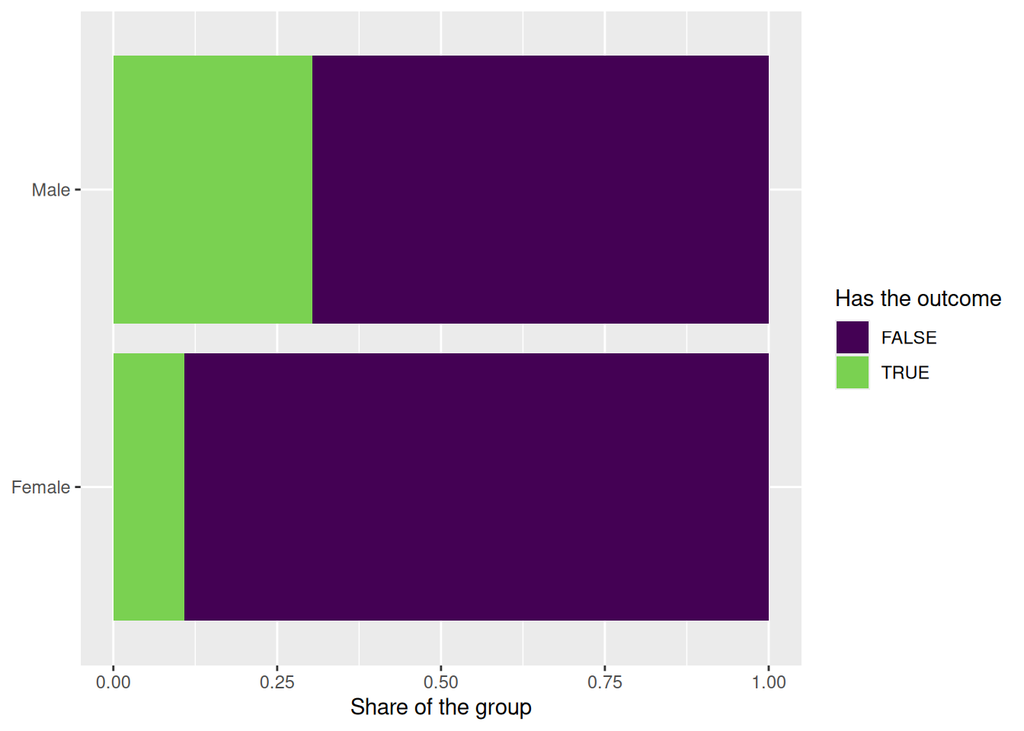

Figure 1: Share of each group with the outcome.

```r
a1 <- ggplot(a_data, aes(y = group, fill = has_outcome)) +
  geom_bar(position = "fill") +
  labs(x = "Share of the group", y = NULL, fill = "Has the outcome")

show_plot(a1)
```

I predicted that males would have a higher rate of earning over $50K than females. The plot confirms that males have the highest rate at roughly 30.4% (1,015 of 3,343), whereas females have the lowest rate at roughly 10.9% (180 of 1,657). Because each bar divides by its own group’s total, groups with very different sample sizes can be compared directly on the same 0 to 1 scale.

### A2 · Rates with their standard error

The A1 rates tell us where the two points should fall. To predict the widths of their error bars, we need both the group sizes and the rates.

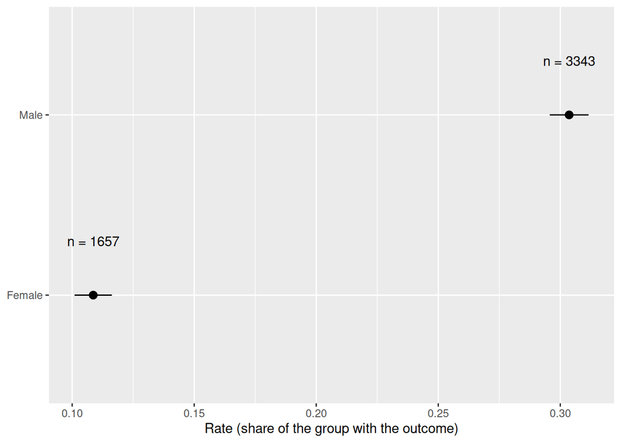

Figure 2: Rate in each group, with ± one standard error and the group size.

```r
a2_rates <- a_data %>%
  drop_na(has_outcome) %>%
  group_by(group) %>%
  summarize(
    n = n(),
    rate = mean(has_outcome),
    se = sqrt(rate * (1 - rate) / n)
  )

a2 <- ggplot(a2_rates,
             aes(x = rate, y = group,
                 xmin = rate - se,
                 xmax = rate + se)) +
  geom_pointrange() +
  # Many groups, and the labels touch the points? Keep every group, and use
  # vjust = -0.8, size = 3 instead of nudge_y = 0.3.
  geom_text(aes(label = paste("n =", n)), nudge_y = 0.3) +
  labs(x = "Rate (share of the group with the outcome)", y = NULL)

show_plot(a2)
```

The male group’s range is slightly wider (SE = 0.795 percentage points, $n = 3,343$) than the female group’s range (SE = 0.764 percentage points, $n = 1,657$). The standard error depends on both the rate and the sample size. A wider range tells the reader that there is greater sampling uncertainty around that group’s estimated rate. Rather than dropping smaller or under-represented groups, this plot keeps them visible by plotting their point estimate alongside their explicit count $n$.

### A3 · Zoom or filter?

The two counts differ by 1,686 people. Starting the axis at 800 should leave that difference intact but make the longer bar look larger relative to the shorter one.

```r
a3_table <- a_data %>%
  count(group) %>%
  arrange(desc(n))
a3_table
```

```
# A tibble: 2 × 2
  group      n
  <chr>  <int>
1 Male    3343
2 Female  1657
```

```r
a3_start <- 800

a3_counts <- ggplot(a_data, aes(y = group)) +
  geom_bar() +
  labs(x = "Count", y = NULL)

a3_zoom <- a3_counts +
  coord_cartesian(xlim = c(a3_start, max(a3_table$n)), expand = FALSE)

# A warning about removed rows here is expected (Session 2, slide 5).
a3_filter <- a3_counts +
  scale_x_continuous(limits = c(a3_start, max(a3_table$n)))

# Lie Factor (Tufte, 2001, p. 57) of the zoomed plot, largest vs smallest
# group: how many times the picture exaggerates the difference.
a3_largest <- max(a3_table$n)
a3_smallest <- min(a3_table$n)
a3_lie_factor <-
  ((a3_largest - a3_start) / (a3_smallest - a3_start)) /
  (a3_largest / a3_smallest)
a3_lie_factor
```

```
[1] 1.470793
```

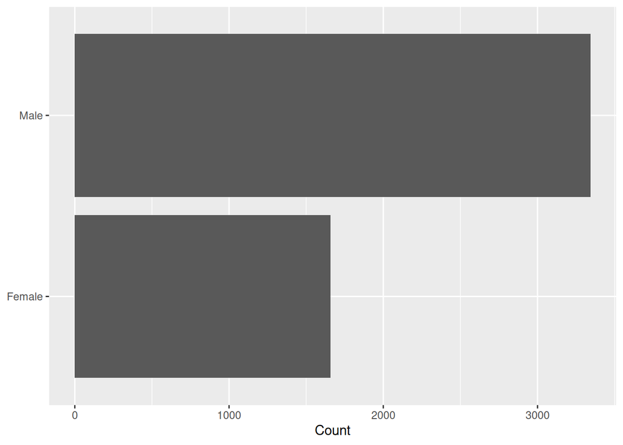

(a) From 0

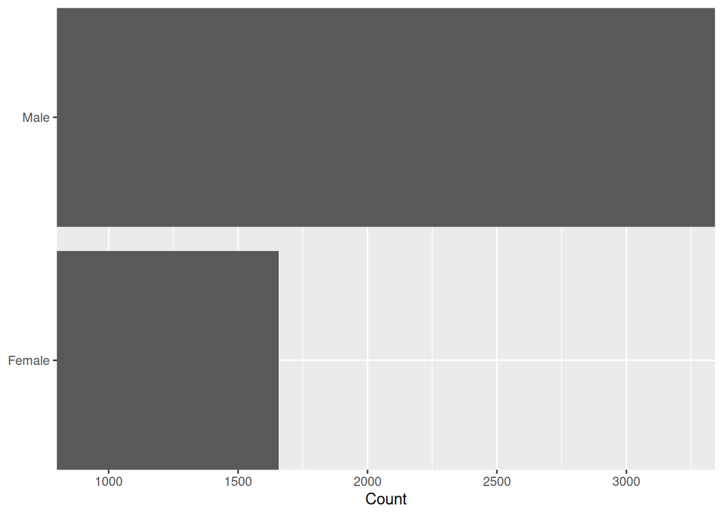

(b) Zoomed

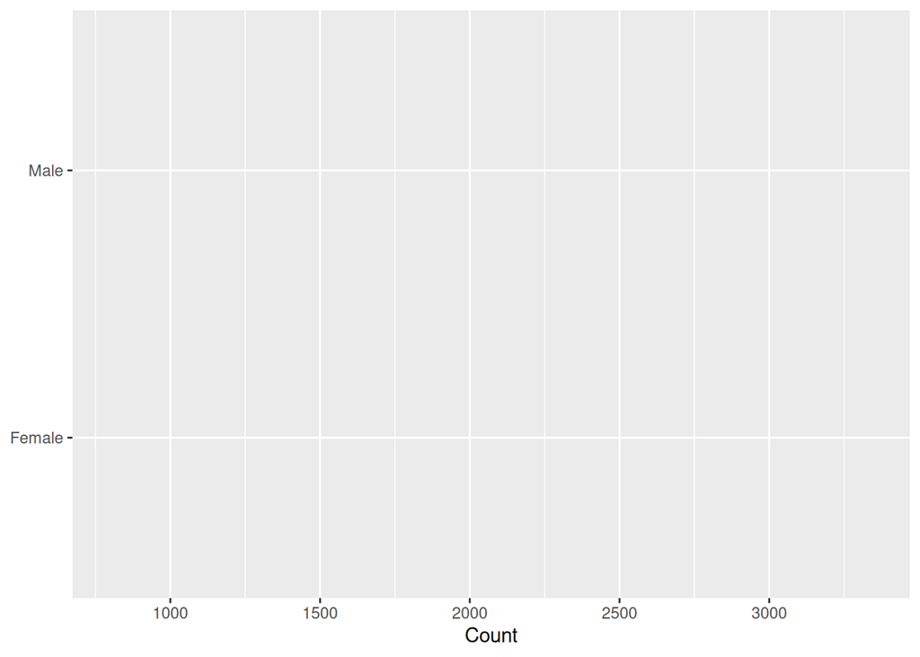

(c) Filtered

Figure 3: Counts per group: from 0, zoomed and filtered.

```r
show_plot(a3_counts)
show_plot(a3_zoom)
show_plot(a3_filter)
```

The zoomed plot’s Lie Factor (largest vs smallest group) is 1.5.

The plot starting from zero shows the true proportional difference between the 3,343 males and 1,657 females, whereas the zoomed plot cuts off the left side of the bars and makes the male bar look nearly three times as long, and the filtered plot drops the bars completely because their zero baseline falls outside the scale limits. The Lie Factor of 1.5 measures how many times the zoomed picture exaggerates the actual ratio between the two group counts. I would publish the first version starting from zero because bar lengths rely on a zero baseline to represent counts honestly.

### A4 · Each group’s share of everyone with the outcome (question B)

The A0 counts give a prediction for this plot: 1,015 of the 1,195 higher-income records are male, so the male bar should take up more than four-fifths of the total share.

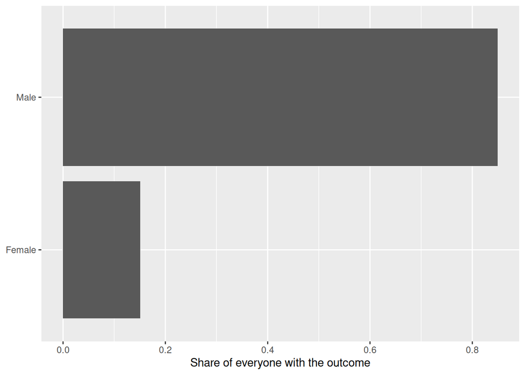

Figure 4: Each group’s share of everyone with the outcome.

```r
a4_shares <- a_data %>%
  filter(has_outcome) %>%
  count(group) %>%
  mutate(share = n / sum(n))

a4 <- ggplot(a4_shares, aes(x = share, y = group)) +
  geom_col() +
  labs(x = "Share of everyone with the outcome", y = NULL)

show_plot(a4)
```

Question A (`A1`, `A2`) and Question B (`A4`) point in the same direction because males both earn over $50K at a higher rate and account for roughly 84.9% (1,015 of 1,195) of everyone in the dataset earning over $50K, amplified by males making up two-thirds of the sample. My Module 11 question requires Question A because comparing rates within each demographic group controls for unequal group sizes.

## Part B · Sports

**My group, outcome and value:** `group = position`, `has_outcome = Round %in% 1`, and `value = forty`.

### B0 · My group, outcome and value

```r
b_data <- sports %>%
  mutate(
    group = position,
    has_outcome = Round %in% 1,
    value = forty
  )

b_data %>%
  count(group, has_outcome) %>%
  print(n = Inf)
```

```
# A tibble: 37 × 3
   group has_outcome     n
   <chr> <lgl>       <int>
 1 C     FALSE         137
 2 C     TRUE           11
 3 CB    FALSE         567
 4 CB    TRUE           73
 5 DB    FALSE          53
 6 DB    TRUE            5
 7 DE    FALSE         353
 8 DE    TRUE           61
 9 DL    FALSE         101
10 DL    TRUE           15
11 DT    FALSE         357
12 DT    TRUE           48
```

[output cut: 25 more lines]

```r
summary(b_data$value)
```

```
   Min. 1st Qu.  Median    Mean 3rd Qu.    Max.     NAs
  4.220   4.530   4.680   4.765   4.960   6.050     377
```

### B1 · The rate within each group

With horizontal bars, all 19 position labels fit down the left side. Each row identifies a position directly, and the two fill colors show whether a player was picked in round one. The B0 counts predict an empty first-round segment for fullbacks: none of the 83 were picked in that round.

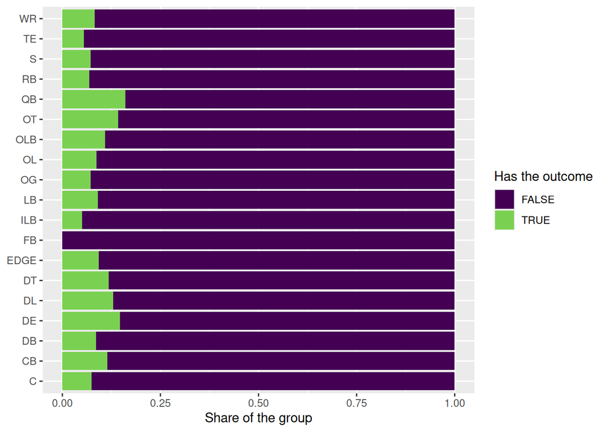

Figure 5: Share of each group with the outcome.

```r
b1 <- ggplot(b_data, aes(y = group, fill = has_outcome)) +
  geom_bar(position = "fill") +
  labs(x = "Share of the group", y = NULL, fill = "Has the outcome")

show_plot(b1)
```

The plot shows the share of combine participants drafted in the first round for each of the 19 football positions, with positions like QB (16.1%) and DE (14.7%) having higher rates while FB has 0%. Using shares rather than raw counts is necessary because total combine participation varies widely across positions, from 886 wide receivers down to 58 defensive backs.

### B2 · A mean with its two spreads

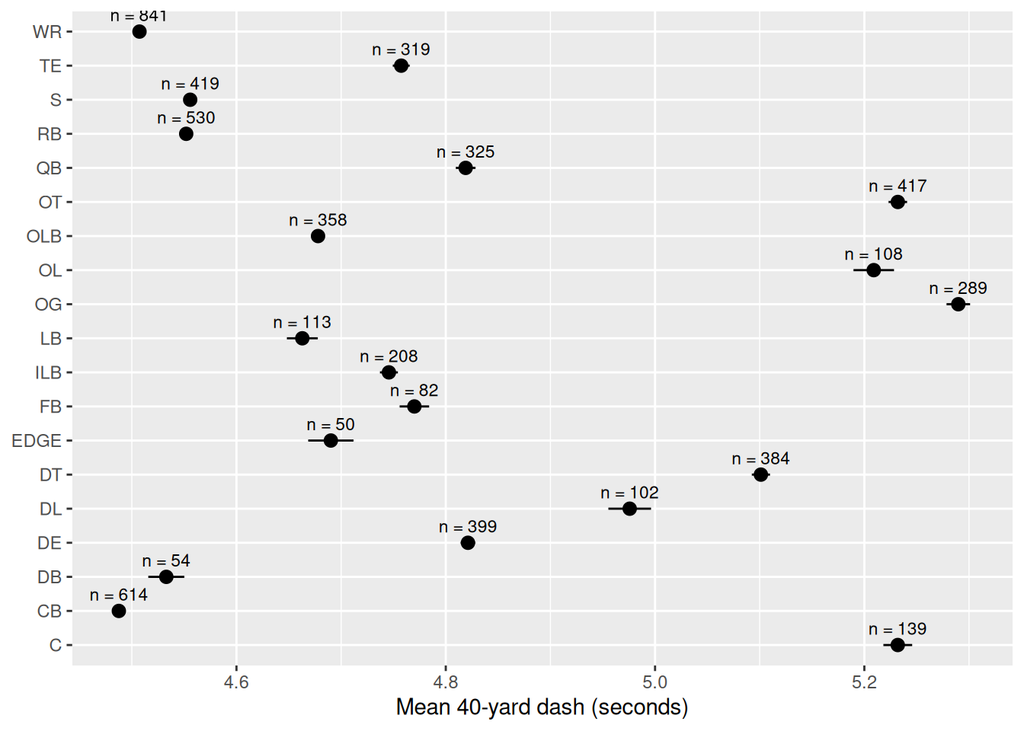

Figure 6: Mean in each group, with ± one standard error and group size.

```r
b2_summary <- b_data %>%
  drop_na(value) %>%
  group_by(group) %>%
  summarize(
    n = n(),
    mean = mean(value),
    sd = sd(value),
    se = sd / sqrt(n)
  )

b2 <- ggplot(b2_summary,
             aes(x = mean, y = group,
                 xmin = mean - se,
                 xmax = mean + se)) +
  geom_pointrange() +
  geom_text(aes(label = paste("n =", n)), vjust = -0.8, size = 3) +
  labs(x = "Mean 40-yard dash (seconds)", y = NULL)

show_plot(b2)
```

Table 1: Group size, mean, sd and se.

| group | n | mean | sd | se |
| --- | --- | --- | --- | --- |
| C | 139 | 5.232 | 0.162 | 0.014 |
| CB | 614 | 4.488 | 0.092 | 0.004 |
| DB | 54 | 4.533 | 0.127 | 0.017 |
| DE | 399 | 4.821 | 0.140 | 0.007 |
| DL | 102 | 4.976 | 0.206 | 0.020 |
| DT | 384 | 5.101 | 0.170 | 0.009 |
| EDGE | 50 | 4.690 | 0.153 | 0.022 |
| FB | 82 | 4.770 | 0.128 | 0.014 |
| ILB | 208 | 4.746 | 0.124 | 0.009 |
| LB | 113 | 4.663 | 0.157 | 0.015 |
| OG | 289 | 5.290 | 0.192 | 0.011 |
| OL | 108 | 5.209 | 0.201 | 0.019 |
| OLB | 358 | 4.678 | 0.116 | 0.006 |
| OT | 417 | 5.232 | 0.181 | 0.009 |
| QB | 325 | 4.819 | 0.170 | 0.009 |
| RB | 530 | 4.552 | 0.109 | 0.005 |
| S | 419 | 4.556 | 0.105 | 0.005 |
| TE | 319 | 4.757 | 0.145 | 0.008 |
| WR | 841 | 4.507 | 0.101 | 0.003 |

Comparing Wide Receivers (`WR`, mean = 4.507 s) and Offensive Tackles (`OT`, mean = 5.232 s), the 0.725-second gap between their means is enormous compared to their standard errors (`se` = 0.003 s and 0.009 s), showing that the position averages are estimated with very high precision. That gap is also substantial compared to their individual standard deviations (`sd` = 0.101 s and 0.181 s), which describe the spread of individual times within each position.

**My Module 11 sports question:** How do 40-yard dash times and vertical jump heights vary across offensive skill positions (QB, RB, WR, TE)?

**My hunch:** WRs and RBs will have faster (lower) 40-yard dash times and higher vertical jumps than QBs and TEs.

This question compares measurements within positions. For each mean, the denominator is the number of players at that position with a recorded result for that drill. B1 and B4 answer separate questions about first-round draft picks.

```r
b_data %>%
  filter(position %in% c("QB", "RB", "WR", "TE")) %>%
  group_by(position) %>%
  summarize(
    dash_n = sum(!is.na(forty)),
    dash_mean = mean(forty, na.rm = TRUE),
    jump_n = sum(!is.na(vertical)),
    jump_mean = mean(vertical, na.rm = TRUE)
  ) %>%
  knitr::kable(digits = 3, col.names = c(
    "Position", "Dash n", "Mean dash (s)", "Jump n", "Mean vertical (in)"
  ))
```

Table 2: Mean combine results for the four positions in my Module 11 question.

| Position | Dash n | Mean dash (s) | Jump n | Mean vertical (in) |
| --- | --- | --- | --- | --- |
| QB | 325 | 4.819 | 286 | 30.981 |
| RB | 530 | 4.552 | 480 | 34.299 |
| TE | 319 | 4.757 | 264 | 32.956 |
| WR | 841 | 4.507 | 748 | 35.202 |

Both comparisons support the hunch in this sample: WR (4.51 s, 35.2 in) and RB (4.55 s, 34.3 in) show faster average 40-yard dash times and higher average vertical jumps than TE (4.76 s, 33.0 in) and QB (4.82 s, 31.0 in).

### B3 · Zoom or filter?

Starting at 1 should change the apparent lengths very little: even the smallest group has 58 players. As in A3, setting scale limits above zero should remove the bars.

```r
b3_table <- b_data %>%
  count(group) %>%
  arrange(desc(n))
b3_table
```

```
# A tibble: 19 × 2
   group     n
   <chr> <int>
 1 WR      886
 2 CB      640
 3 RB      555
 4 S       458
 5 OT      442
 6 DE      414
 7 DT      405
 8 OLB     360
 9 QB      348
10 TE      346
11 OG      293
12 ILB     219
13 LB      154
14 C       148
15 OL      138
16 DL      116
17 FB       83
18 EDGE     65
19 DB       58
```

```r
b3_start <- 1

b3_counts <- ggplot(b_data, aes(y = group)) +
  geom_bar() +
  labs(x = "Count", y = NULL)

b3_zoom <- b3_counts +
  coord_cartesian(xlim = c(b3_start, max(b3_table$n)), expand = FALSE)

b3_filter <- b3_counts +
  scale_x_continuous(limits = c(b3_start, max(b3_table$n)))

b3_lie_factor <-
  ((max(b3_table$n) - b3_start) / (min(b3_table$n) - b3_start)) /
  (max(b3_table$n) / min(b3_table$n))
b3_lie_factor
```

```
[1] 1.016395
```

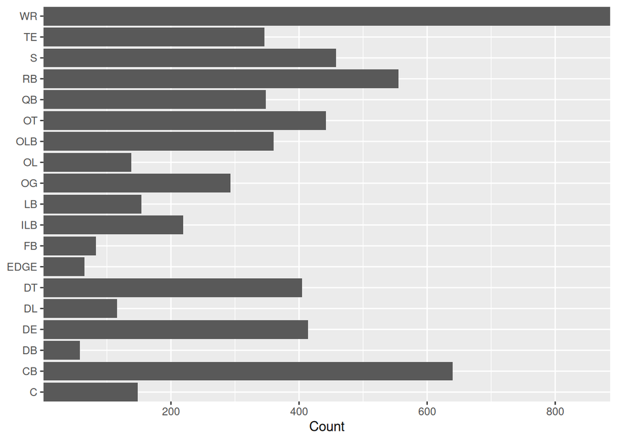

(a) Zoomed

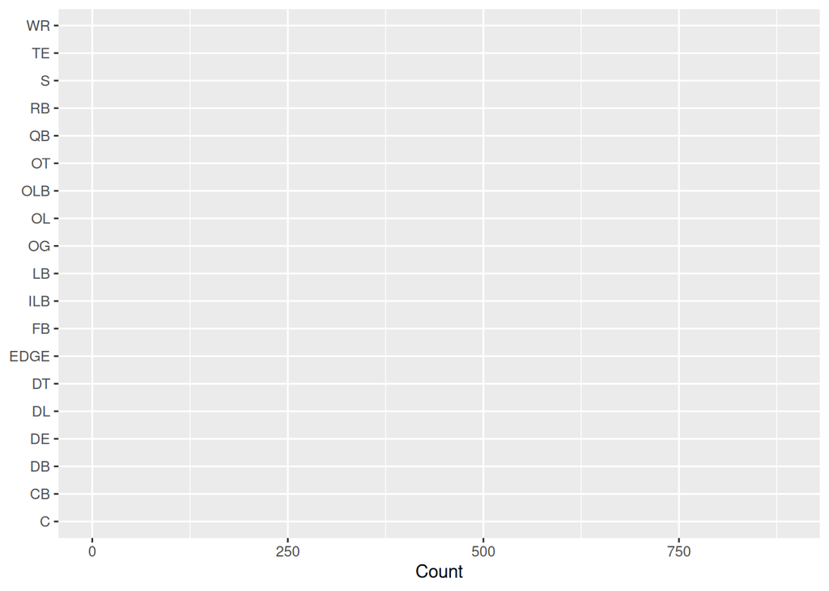

(b) Filtered

Figure 7: Counts per group: zoomed and filtered.

```r
show_plot(b3_zoom)
show_plot(b3_filter)
```

The Lie Factor of the zoomed plot is 1.016.

Because `b3_start` is set to 1 relative to a maximum count of 886 (`WR`) and minimum of 58 (`DB`), the Lie Factor is near 1.0, meaning the zoomed plot barely distorts the visual comparison, whereas the filtered plot removes all 19 bars because their starting baseline at 0 falls outside the `limits = c(1, 886)` scale. This dataset does not include a year or season column, so all combine eras are pooled together.

### B4 · Each group’s share of everyone with the outcome

Since WR and CB each have 73 first-round picks and now share the same denominator, their bars should be the same length. FB should stay on the axis with a share of zero.

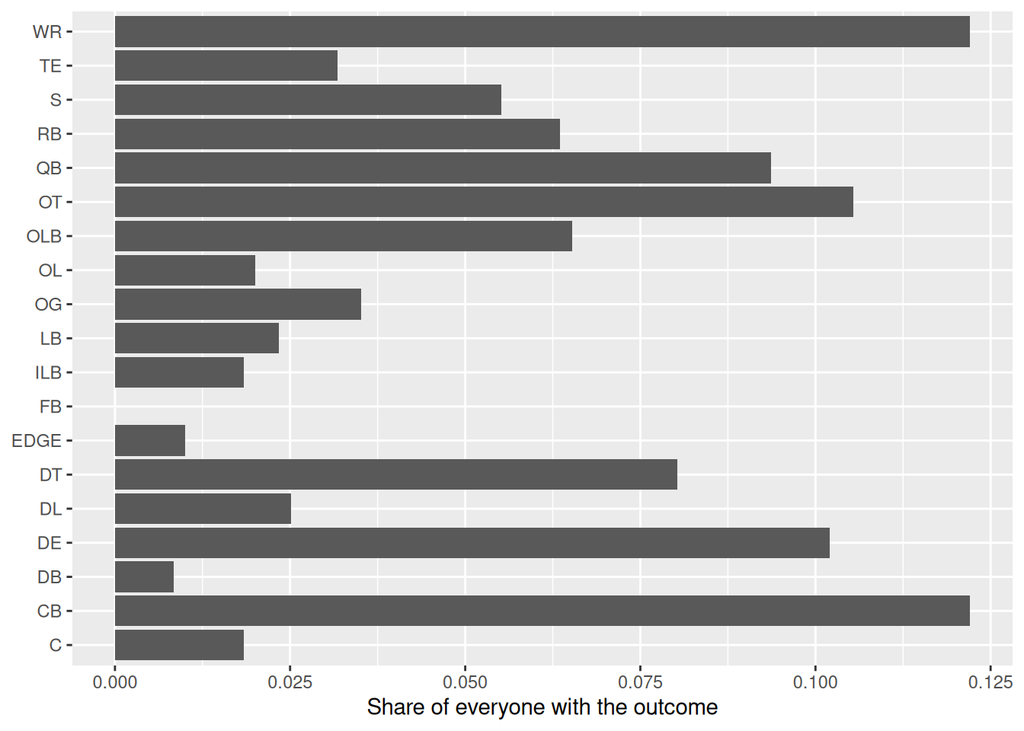

Figure 8: Each group’s share of everyone with the outcome.

```r
b4_shares <- b_data %>%
  group_by(group) %>%
  summarize(n = sum(has_outcome, na.rm = TRUE), .groups = "drop") %>%
  mutate(share = n / sum(n))

b4 <- ggplot(b4_shares, aes(x = share, y = group)) +
  geom_col() +
  labs(x = "Share of everyone with the outcome", y = NULL)

show_plot(b4)
```

Unlike `B1` where Quarterbacks (`QB`) had the highest first-round draft rate, `B4` shows that Wide Receivers (`WR`) and Cornerbacks (`CB`) make up the largest shares of all first-round draft picks (73 of 598 picks each, or 12.2%). They do not point in the exact same direction because `WR` and `CB` have much larger total combine pools than `QB`, giving them more total first-round picks despite a lower per-player selection rate.

## Checks

Table 3: Every task’s check, at the time this page was rendered.

| task | status |
| --- | --- |
| A0 | PASS |
| A1 | PASS |
| A2 | PASS |
| A3 | PASS |
| A4 | PASS |
| B0 | PASS |
| B1 | PASS |
| B2 | PASS |
| B3 | PASS |
| B4 | PASS |

## AI use

AI use: I used ChatGPT to review my work for errors.

## References

- Fairlearn Contributors. (2021). *Fairlearn: Assessing and improving fairness of AI systems* [Adult dataset]. https://fairlearn.org/
- Kohavi, R. (1996). Scaling up the accuracy of Naive-Bayes classifiers: A decision-tree hybrid. *Proceedings of the Second International Conference on Knowledge Discovery and Data Mining (KDD-96)*, 202–207. https://archive.ics.uci.edu/dataset/2/adult
- SCORE Network. (2026). *NFL Draft Combine Dataset*. Sports Content for Outreach, Research, and Education. https://data.scorenetwork.org/